# Tutorial: Bayesian Linear Regression via Exact Sampling in JAGS

Sudipto Banerjee

2026-07-30

```bash
# Navigate to the directory and run the compilation script
cd src/bayesianLinearRegressionExact/rjags/run
./renderRaw.sh
```

## Introduction

In standard MCMC applications, sampling from target posterior distributions is achieved via Markov chains (such as Gibbs sampling or Metropolis-Hastings) that require burn-in periods and convergence diagnostics. However, for conjugate normal-linear models, exact posterior samples can be drawn directly using **Composition Sampling**.

This tutorial demonstrates four distinct computational approaches to exact posterior inference for linear regression under the prior covariance $M_0$ and prior mean $M_0 m_0$ parameterization:

1. **Replicated JAGS Composition Sampler**: Uses a parallel universe / replicated likelihood trick inside JAGS to achieve exact composition sampling without standard MCMC iterations.
2. **Direct JAGS Composition Sampler**: A likelihood-free / direct variation of the composition sampler in JAGS.
3. **Replicated JAGS vs. `spBayes::bayesLMConjugate`**: Direct validation of Replicated JAGS draws against closed-form analytical conjugate sampling in `spBayes`.
4. **Direct JAGS vs. `spBayes::bayesLMConjugate`**: Direct validation of Likelihood-Free JAGS draws against `spBayes`.

## 1. Environment Setup & Data Preparation

We begin by loading the required packages and reading the dataset located at `../../data/data.txt` relative to our working directory (`rjags/run`).

### Model Specification ($M_0$ Prior Covariance Parameterization)

Consider the standard linear regression model:

$$Y = X\beta + \varepsilon, \quad
\varepsilon \sim \mathcal{N}(0, \sigma^2 I_N)$$

We assign conjugate Normal-Inverse-Gamma priors specified via prior covariance matrix factor $M_0$ and prior mean vector $M_0 m_0$:

$$\beta \mid \sigma^2 \sim \mathcal{N}(M_0
m_0, \sigma^2 M_0)$$
$$\tau =
\frac{1}{\sigma^2} \sim \text{Gamma}(a_0, b_0)$$

The joint posterior density, which is proportional to the joint density of the parameters and the data (prior $\times$ likelihood), can be seen to factorize as (after some algebra involving completion of squares):
$$\begin{align*}
p(\beta,\tau \mid Y) &\propto
\begin{array}{ccc}
\underbrace{\text{Gamma}(\tau\mid a_N, b_N)} & \times &
\underbrace{\mathcal{N}\left(\beta \mid Mm, \tau^{-1} M\right)}\\
p(\tau\mid Y) & & p(\beta\mid \tau, Y)
\end{array}\;,
\end{align*}$$
where
$$\begin{align*}
& m = m_0 + X^{\top}Y\;;\quad M^{-1} = M_0^{-1} + X^{\top} X\;;\\
& a_N = a_0 + \frac{N}{2}\;;\quad b_N = b_0 +
\frac{1}{2}\left(m_0^{\top}M_0m_0 + Y^{\top}Y - m^{\top}Mm\right)\;.
\end{align*}$$

The conjugate posterior parameters are updated via Cholesky factorizations ($R_0 = \text{chol}(M_0)$ and $R_N = \text{chol}(M^{-1})$):

$$M^{-1} = M_0^{-1} + X^{\top} X =
\text{chol2inv}(R_0) + X^{\top} X$$
$$m = m_0 + X^{\top} Y \implies \mu = M m \quad
(\text{solved via } R_N^{\top}\omega=m \text{ to get $\omega$ and then
solved for $\mu$ via } R_N \mu = \omega)$$
$$a_N = a_0 + \frac{N}{2}$$
$$b_N = b_0 + \frac{1}{2} \left[ Y^{\top} Y +
m_0^{\top}M_0m_0 - \mu^{\top}m \right]$$

```r
library(spBayes)
library(rjags)
library(knitr)

# Source JAGS wrappers from relative source path
source("../src/compositionSamplingJAGS.r")
source("../src/compositionSamplingJAGSDirect.r")

# Load data from project-level data directory
rawData <- read.table("../../data/data.txt", header = TRUE)

# Prepare response and scaled design matrix
Y <- rawData$Y
X_raw <- as.matrix(rawData[, -1])
X_scaled <- scale(X_raw)
X <- cbind(Intercept = 1, X_scaled)

N <- nrow(X)
P <- ncol(X)
n_samples <- 5000

# Shared prior specification (M0 = prior covariance factor)
M0 <- diag(100, P)
m0 <- rep(0, P) # mu0_vec = M0 %*% m0 = 0
a0 <- 0.01
b0 <- 0.01

cat("Dataset loaded successfully:", N, "observations and", P, "predictors (including Intercept).\n")
```

```
## Dataset loaded successfully: 1369 observations and 9 predictors (including Intercept).
```

## 2. Replicated Likelihood JAGS Sampler (`lmExactJags.r`)

In this section, we execute exact composition sampling using `run_replicated_jags_composition()`. This function draws exact posterior samples without relying on Markov chain convergence.

```r
set.seed(123)

cat("Executing parallel universe composition sampling in JAGS...\n")
```

```
## Executing parallel universe composition sampling in JAGS...
```

```r
jags_rep_results <- run_replicated_jags_composition(
  X = X,
  Y = Y,
  M_samples = n_samples,
  a0 = a0,
  b0 = b0,
  m0 = m0,
  M0 = M0
)

rep_samples <- jags_rep_results$draws

# Summary statistics (transposition via crossprod against identity matrix)
rep_means     <- colMeans(rep_samples)
rep_sds       <- apply(rep_samples, 2, sd)
rep_quantiles <- crossprod(apply(rep_samples, 2, quantile, probs = c(0.5, 0.025, 0.975)), diag(3))

summary_rep <- round(cbind(Mean = rep_means, SD = rep_sds, rep_quantiles), 4)
kable(summary_rep, caption = "JAGS Replicated Likelihood Posterior Summary")
```

JAGS Replicated Likelihood Posterior Summary

|  | Mean | SD |  |  |  |
| --- | --- | --- | --- | --- | --- |
| Intercept | 11.6840 | 0.0042 | 11.6840 | 11.6756 | 11.6924 |
| X1 | 0.2963 | 0.0060 | 0.2962 | 0.2847 | 0.3079 |
| X2 | -0.0386 | 0.0062 | -0.0386 | -0.0510 | -0.0265 |
| X3 | -0.0346 | 0.0059 | -0.0346 | -0.0462 | -0.0231 |
| X4 | -0.0327 | 0.0042 | -0.0327 | -0.0411 | -0.0242 |
| X5 | 0.0129 | 0.0042 | 0.0129 | 0.0047 | 0.0212 |
| X6 | 0.1114 | 0.0220 | 0.1117 | 0.0675 | 0.1538 |
| Lat | -0.0649 | 0.0085 | -0.0648 | -0.0815 | -0.0483 |
| Longi | -0.1454 | 0.0224 | -0.1457 | -0.1894 | -0.1005 |
| sigma2 | 0.0238 | 0.0009 | 0.0237 | 0.0220 | 0.0256 |
| tau | 42.1309 | 1.6143 | 42.1131 | 39.0095 | 45.3874 |
| sigma | 0.1541 | 0.0030 | 0.1541 | 0.1484 | 0.1601 |

## 3. Direct Composition Sampler in JAGS (`lmExactJagsDirect.r`)

Next, we evaluate the direct composition sampler using `run_direct_jags_composition()`.

```r
set.seed(123)

cat("Executing exact direct sampling in JAGS (Likelihood-Free)...\n")
```

```
## Executing exact direct sampling in JAGS (Likelihood-Free)...
```

```r
jags_dir_results <- run_direct_jags_composition(
  X = X,
  Y = Y,
  n_samples = n_samples,
  a0 = a0,
  b0 = b0,
  m0 = m0,
  M0 = M0
)

dir_samples <- jags_dir_results$draws

# Summary statistics (transposition via crossprod against identity matrix)
dir_means     <- colMeans(dir_samples)
dir_sds       <- apply(dir_samples, 2, sd)
dir_quantiles <- crossprod(apply(dir_samples, 2, quantile, probs = c(0.5, 0.025, 0.975)), diag(3))

summary_dir <- round(cbind(Mean = dir_means, SD = dir_sds, dir_quantiles), 4)
kable(summary_dir, caption = "JAGS Direct Posterior Summary (Likelihood-Free)")
```

JAGS Direct Posterior Summary (Likelihood-Free)

|  | Mean | SD |  |  |  |
| --- | --- | --- | --- | --- | --- |
| Intercept | 11.6839 | 0.0042 | 11.6839 | 11.6757 | 11.6920 |
| X1 | 0.2964 | 0.0058 | 0.2964 | 0.2852 | 0.3080 |
| X2 | -0.0385 | 0.0063 | -0.0386 | -0.0508 | -0.0264 |
| X3 | -0.0347 | 0.0059 | -0.0348 | -0.0459 | -0.0229 |
| X4 | -0.0328 | 0.0043 | -0.0327 | -0.0412 | -0.0244 |
| X5 | 0.0129 | 0.0042 | 0.0128 | 0.0047 | 0.0211 |
| X6 | 0.1116 | 0.0218 | 0.1115 | 0.0705 | 0.1549 |
| Lat | -0.0649 | 0.0085 | -0.0648 | -0.0818 | -0.0486 |
| Longi | -0.1457 | 0.0222 | -0.1457 | -0.1897 | -0.1035 |
| sigma2 | 0.0238 | 0.0009 | 0.0238 | 0.0221 | 0.0256 |
| tau | 42.0950 | 1.5864 | 42.0938 | 39.0345 | 45.3149 |
| sigma | 0.1542 | 0.0029 | 0.1541 | 0.1486 | 0.1601 |

## 4. Replicated JAGS vs. `spBayes::bayesLMConjugate` (`lmExactJagsVsBayesLMConjugate.r`)

We now compare the draws from the Replicated JAGS composition sampler against the analytical draws generated by `spBayes::bayesLMConjugate()`.

```r
df <- data.frame(Y = Y, X_scaled)

# 1. Run Replicated JAGS
set.seed(123)
jags_rep <- run_replicated_jags_composition(
  X = X, Y = Y, M_samples = n_samples,
  a0 = a0, b0 = b0, m0 = m0, M0 = M0
)$draws

# 2. Run spBayes (prior precision computed via chol2inv(chol(M0)))
set.seed(123)
spb_model_1 <- bayesLMConjugate(
  formula = Y ~ ., data = df, n.samples = n_samples,
  beta.prior.mean = as.vector(crossprod(chol(M0), chol(M0) %*% m0)),
  beta.prior.precision = chol2inv(chol(M0)),
  prior.shape = a0, prior.rate = b0
)

# Extract and align spBayes parameter columns
spb_raw1     <- spb_model_1$p.beta.tauSq.samples
spb_var1     <- spb_raw1[, P + 1]
spb_sigma1   <- sqrt(spb_var1)
spb_tau1     <- 1 / spb_var1

spb_samples1 <- cbind(spb_raw1[, 1:P], sigma2 = spb_var1, tau = spb_tau1, sigma = spb_sigma1)
colnames(spb_samples1) <- colnames(jags_rep)

# Display Posterior Summaries
s_jags_rep <- round(cbind(Mean = colMeans(jags_rep), SD = apply(jags_rep, 2, sd),
                           crossprod(apply(jags_rep, 2, quantile, probs = c(0.5, 0.025, 0.975)), diag(3))), 4)

s_spb1     <- round(cbind(Mean = colMeans(spb_samples1), SD = apply(spb_samples1, 2, sd),
                           crossprod(apply(spb_samples1, 2, quantile, probs = c(0.5, 0.025, 0.975)), diag(3))), 4)

kable(s_jags_rep, caption = "Posterior Summary: Replicated JAGS Sampler")
```

Posterior Summary: Replicated JAGS Sampler

|  | Mean | SD |  |  |  |
| --- | --- | --- | --- | --- | --- |
| Intercept | 11.6839 | 0.0041 | 11.6839 | 11.6757 | 11.6921 |
| X1 | 0.2964 | 0.0059 | 0.2963 | 0.2847 | 0.3079 |
| X2 | -0.0387 | 0.0062 | -0.0387 | -0.0509 | -0.0264 |
| X3 | -0.0348 | 0.0060 | -0.0347 | -0.0465 | -0.0231 |
| X4 | -0.0328 | 0.0043 | -0.0328 | -0.0412 | -0.0243 |
| X5 | 0.0128 | 0.0042 | 0.0128 | 0.0046 | 0.0212 |
| X6 | 0.1115 | 0.0217 | 0.1114 | 0.0694 | 0.1541 |
| Lat | -0.0650 | 0.0084 | -0.0649 | -0.0815 | -0.0481 |
| Longi | -0.1456 | 0.0220 | -0.1454 | -0.1885 | -0.1029 |
| sigma2 | 0.0238 | 0.0009 | 0.0237 | 0.0220 | 0.0256 |
| tau | 42.1448 | 1.6091 | 42.1480 | 39.0034 | 45.3583 |
| sigma | 0.1541 | 0.0029 | 0.1540 | 0.1485 | 0.1601 |

```r
kable(s_spb1, caption = "Posterior Summary: spBayes::bayesLMConjugate")
```

Posterior Summary: spBayes::bayesLMConjugate

|  | Mean | SD |  |  |  |
| --- | --- | --- | --- | --- | --- |
| Intercept | 11.6840 | 0.0041 | 11.6841 | 11.6758 | 11.6918 |
| X1 | 0.2964 | 0.0059 | 0.2964 | 0.2847 | 0.3081 |
| X2 | -0.0386 | 0.0062 | -0.0388 | -0.0505 | -0.0261 |
| X3 | -0.0347 | 0.0059 | -0.0347 | -0.0462 | -0.0230 |
| X4 | -0.0328 | 0.0043 | -0.0329 | -0.0412 | -0.0243 |
| X5 | 0.0128 | 0.0041 | 0.0127 | 0.0048 | 0.0210 |
| X6 | 0.1112 | 0.0215 | 0.1108 | 0.0687 | 0.1531 |
| Lat | -0.0648 | 0.0084 | -0.0649 | -0.0812 | -0.0478 |
| Longi | -0.1452 | 0.0220 | -0.1452 | -0.1878 | -0.1019 |
| sigma2 | 0.0238 | 0.0009 | 0.0238 | 0.0221 | 0.0257 |
| tau | 42.0868 | 1.5894 | 42.0699 | 38.9838 | 45.2475 |
| sigma | 0.1542 | 0.0029 | 0.1542 | 0.1487 | 0.1602 |

### Diagnostics: Q-Q Plots ($R^2$ Comparison)

To verify that the empirical distributions match, we construct quantile-quantile (Q-Q) plots for each parameter and compute the $R^2$ coefficient between sorted quantiles.

```r
# Save PNG copy to disk
png("comparisonsJagsVsSpBayesQ-Qplots.png", width = 1200, height = 900, res = 150)
par(mfrow = c(3, 4), mar = c(4, 4, 2, 1))

param_names <- colnames(jags_rep)

for (param in param_names) {
  x_jags    <- sort(jags_rep[, param])
  y_spbayes <- sort(spb_samples1[, param])
  r2        <- cor(x_jags, y_spbayes)^2

  plot(x_jags, y_spbayes,
       main = param,
       xlab = "composition sampling in rjags",
       ylab = "bayesLMConjugate in spBayes",
       pch = 20, col = rgb(0.1, 0.2, 0.7, alpha = 0.5))

  abline(a = 0, b = 1, col = "red", lwd = 2)
  legend("topleft", legend = bquote(R^2 == .(format(r2, digits = 4))),
         bty = "n", text.col = "black")
}
par(mfrow = c(1, 1))
dev.off()
```

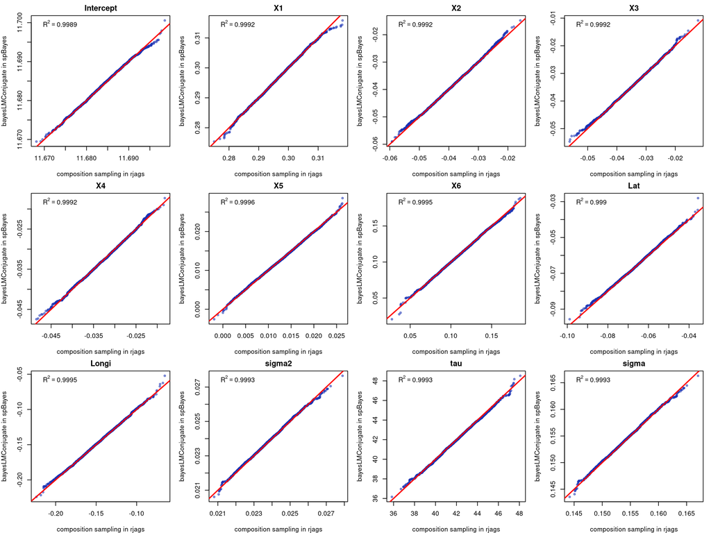

```r
# Re-plot inline for the knitted Rmd report
par(mfrow = c(3, 4), mar = c(4, 4, 2, 1))
for (param in param_names) {
  x_jags    <- sort(jags_rep[, param])
  y_spbayes <- sort(spb_samples1[, param])
  r2        <- cor(x_jags, y_spbayes)^2

  plot(x_jags, y_spbayes,
       main = param,
       xlab = "composition sampling in rjags",
       ylab = "bayesLMConjugate in spBayes",
       pch = 20, col = rgb(0.1, 0.2, 0.7, alpha = 0.5))

  abline(a = 0, b = 1, col = "red", lwd = 2)
  legend("topleft", legend = bquote(R^2 == .(format(r2, digits = 4))),
         bty = "n", text.col = "black")
}
```

```r
par(mfrow = c(1, 1))
```

## 5. Direct JAGS vs. `spBayes::bayesLMConjugate` (`lmExactJagsDirectVsBayesLMConjugate.r`)

Finally, we validate the Direct JAGS composition sampler against `spBayes::bayesLMConjugate()`.

```r
# 1. Run Direct JAGS
set.seed(123)
jags_dir <- run_direct_jags_composition(
  X = X, Y = Y, n_samples = n_samples,
  a0 = a0, b0 = b0, m0 = m0, M0 = M0
)$draws

# 2. Run spBayes (prior precision computed via chol2inv(chol(M0)))
set.seed(123)
spb_model_2 <- bayesLMConjugate(
  formula = Y ~ ., data = df, n.samples = n_samples,
  beta.prior.mean = as.vector(crossprod(chol(M0), chol(M0) %*% m0)),
  beta.prior.precision = chol2inv(chol(M0)),
  prior.shape = a0, prior.rate = b0
)

# Extract and align spBayes parameter columns
spb_raw2     <- spb_model_2$p.beta.tauSq.samples
spb_var2     <- spb_raw2[, P + 1]
spb_sigma2   <- sqrt(spb_var2)
spb_tau2     <- 1 / spb_var2

spb_samples2 <- cbind(spb_raw2[, 1:P], sigma2 = spb_var2, tau = spb_tau2, sigma = spb_sigma2)
colnames(spb_samples2) <- colnames(jags_dir)

# Display Posterior Summaries
s_jags_dir <- round(cbind(Mean = colMeans(jags_dir), SD = apply(jags_dir, 2, sd),
                           crossprod(apply(jags_dir, 2, quantile, probs = c(0.5, 0.025, 0.975)), diag(3))), 4)

s_spb2     <- round(cbind(Mean = colMeans(spb_samples2), SD = apply(spb_samples2, 2, sd),
                           crossprod(apply(spb_samples2, 2, quantile, probs = c(0.5, 0.025, 0.975)), diag(3))), 4)

kable(s_jags_dir, caption = "Posterior Summary: Direct JAGS Sampler")
```

Posterior Summary: Direct JAGS Sampler

|  | Mean | SD |  |  |  |
| --- | --- | --- | --- | --- | --- |
| Intercept | 11.6840 | 0.0042 | 11.6838 | 11.6760 | 11.6924 |
| X1 | 0.2964 | 0.0059 | 0.2965 | 0.2848 | 0.3080 |
| X2 | -0.0387 | 0.0061 | -0.0387 | -0.0510 | -0.0267 |
| X3 | -0.0349 | 0.0060 | -0.0349 | -0.0465 | -0.0230 |
| X4 | -0.0328 | 0.0043 | -0.0327 | -0.0411 | -0.0247 |
| X5 | 0.0128 | 0.0042 | 0.0128 | 0.0045 | 0.0208 |
| X6 | 0.1116 | 0.0220 | 0.1117 | 0.0677 | 0.1540 |
| Lat | -0.0650 | 0.0083 | -0.0651 | -0.0812 | -0.0485 |
| Longi | -0.1456 | 0.0224 | -0.1455 | -0.1889 | -0.1008 |
| sigma2 | 0.0238 | 0.0009 | 0.0237 | 0.0221 | 0.0256 |
| tau | 42.1290 | 1.6111 | 42.1236 | 39.0615 | 45.2475 |
| sigma | 0.1542 | 0.0030 | 0.1541 | 0.1487 | 0.1600 |

```r
kable(s_spb2, caption = "Posterior Summary: spBayes::bayesLMConjugate")
```

Posterior Summary: spBayes::bayesLMConjugate

|  | Mean | SD |  |  |  |
| --- | --- | --- | --- | --- | --- |
| Intercept | 11.6840 | 0.0041 | 11.6841 | 11.6758 | 11.6918 |
| X1 | 0.2964 | 0.0059 | 0.2964 | 0.2847 | 0.3081 |
| X2 | -0.0386 | 0.0062 | -0.0388 | -0.0505 | -0.0261 |
| X3 | -0.0347 | 0.0059 | -0.0347 | -0.0462 | -0.0230 |
| X4 | -0.0328 | 0.0043 | -0.0329 | -0.0412 | -0.0243 |
| X5 | 0.0128 | 0.0041 | 0.0127 | 0.0048 | 0.0210 |
| X6 | 0.1112 | 0.0215 | 0.1108 | 0.0687 | 0.1531 |
| Lat | -0.0648 | 0.0084 | -0.0649 | -0.0812 | -0.0478 |
| Longi | -0.1452 | 0.0220 | -0.1452 | -0.1878 | -0.1019 |
| sigma2 | 0.0238 | 0.0009 | 0.0238 | 0.0221 | 0.0257 |
| tau | 42.0868 | 1.5894 | 42.0699 | 38.9838 | 45.2475 |
| sigma | 0.1542 | 0.0029 | 0.1542 | 0.1487 | 0.1602 |

### Diagnostics: Q-Q Plots ($R^2$ Comparison)

```r
# Save PNG copy to disk
png("comparisonsJagsDirectVsSpBayesQ-Qplots.png", width = 1200, height = 900, res = 150)
par(mfrow = c(3, 4), mar = c(4, 4, 2, 1))

param_names <- colnames(jags_dir)

for (param in param_names) {
  x_jags    <- sort(jags_dir[, param])
  y_spbayes <- sort(spb_samples2[, param])
  r2        <- cor(x_jags, y_spbayes)^2

  plot(x_jags, y_spbayes,
       main = param,
       xlab = "composition sampling in rjags",
       ylab = "bayesLMConjugate sampler in spBayes",
       pch = 20, col = rgb(0.1, 0.2, 0.7, alpha = 0.5))

  abline(a = 0, b = 1, col = "red", lwd = 2)
  legend("topleft", legend = bquote(R^2 == .(format(r2, digits = 4))),
         bty = "n", text.col = "black")
}
par(mfrow = c(1, 1))
dev.off()
```

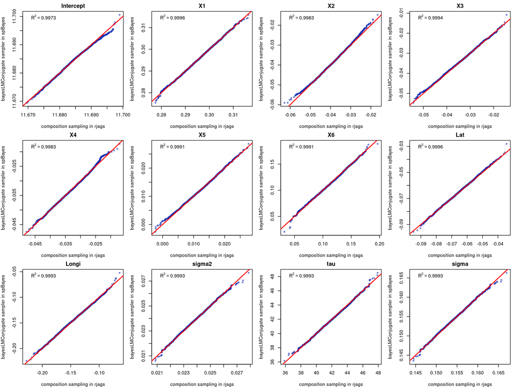

```r
# Re-plot inline for the knitted Rmd report
par(mfrow = c(3, 4), mar = c(4, 4, 2, 1))
for (param in param_names) {
  x_jags    <- sort(jags_dir[, param])
  y_spbayes <- sort(spb_samples2[, param])
  r2        <- cor(x_jags, y_spbayes)^2

  plot(x_jags, y_spbayes,
       main = param,
       xlab = "composition sampling in rjags",
       ylab = "bayesLMConjugate sampler in spBayes",
       pch = 20, col = rgb(0.1, 0.2, 0.7, alpha = 0.5))

  abline(a = 0, b = 1, col = "red", lwd = 2)
  legend("topleft", legend = bquote(R^2 == .(format(r2, digits = 4))),
         bty = "n", text.col = "black")
}
```

```r
par(mfrow = c(1, 1))
```

## 6. Summary & Key Takeaways

1. **Exact Posterior Agreement**: Both JAGS composition sampling approaches (Replicated and Direct) match the analytical conjugate sampling from `spBayes::bayesLMConjugate` with $R^2 \approx 1.000$ across all quantile distributions.
2. **Numerical Stability**: By substituting general matrix inversions (`solve`) with Cholesky factorizations (`chol`, `chol2inv`) and forward/back substitutions (`forwardsolve`, `backsolve`), linear solves are performed with optimal numerical precision and $\mathcal{O}(P^3/3)$ efficiency.
3. **Efficiency**: While the Replicated Likelihood approach requires $M$ copies of $Y$ in memory, the Direct Composition approach is highly memory-efficient while achieving identical posterior accuracy.